# Quiz1A

**Instructions**:

- Select the best answer for each question.
- Use only #2 pencil.
- You must print your name and fill student ID number (nine digits).
- Mark **A** in Test Form field.
- Completely fill in each circle.
- Do not fold the answer sheet.
- Do not make random marks anywhere on exam sheet.
- If you are erasing a mistake, then completely remove all pencil marks from the incorrect answer. Do not put X through it.
1. Which is a categorical variable below?

   (a) length of time between arrivals of buses at a terminal

   (b) depth of sediments in a riverbed

   (c) score received in a homework out of 100 points

   (d) manufacturer of a car parked in a parking lot
2. The frequency table of the weights (in lbs.) of $n$ trouts caught from a lake is given below.

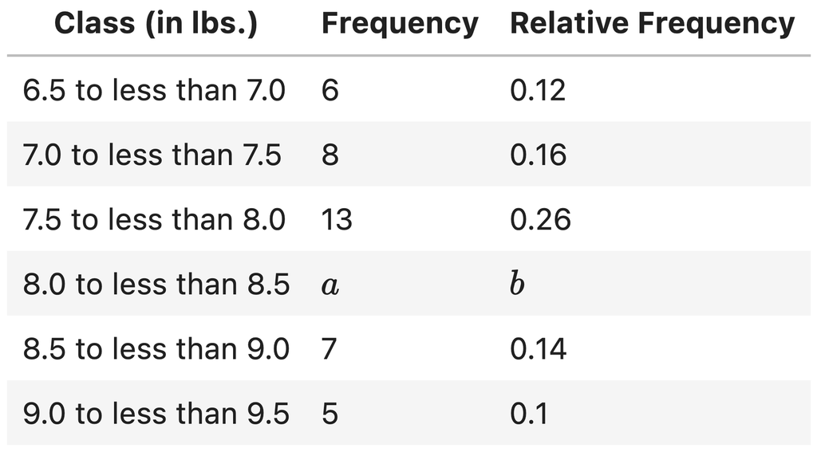

   What is the value of $a$?

   (a) 12 (b) 11 (c) 7 (d) 15
3. The standard deviation of a data set is $4$. If $2$ is added to each measurement, the standard deviation of the resulting data set is

   (a) 2 (b) 4 (c) 6 (d) 8
4. A fair die is tossed twice and event $E_1=$ the sum of two tosses equals to $7$, event $E_2=$ the first toss is $3$. Which of the following is true?

   (a) $E_1$ and $E_2$ are disjoint.

   (b) $E_1$ and $E_2^C$ are independent.

   (c) $E_1$ is a subset of $E_2$.

   (d) None of the above.
5. Let $Y$ be a discrete random variable given by the pmf: $P(Y=0)=0.6, P(Y=1)=0.4$. Calculate the variance $\sigma_Y^2$.

   (a) 1.0 (b) 0.4 (c) 0.6 (d) 0.24
6. Suppose $X\sim\mathrm{B}(4, \frac{3}{4})$. What is $P(X=2)$?

   (a) $\frac{81}{256}$ (b) $\frac{12}{256}$ (c) $\frac{54}{256}$ (d) $\frac{108}{256}$
7. Suppose you flip a fair coin twice. Let $Y$ denote the number of heads you get. Find $P(Y=0|Y\leq1)$.

   (a) 1/3 (b) 1/4 (c) 1/2 (d) 3/4
8. Let $Y$ be a continuous random variable and $c$ be a constant. Which of the following statements is **FALSE**?

   (a) The probability that $Y$ assumes a value in the interval $(y_1, y_2)$ (where $y_1<y_2$) is the area under the probability density function between $y_1$ and $y_2$.

   (b) $P(Y=c)=0$.

   (c) $P(Y>c)=1-P(Y<c)$.

   (d) None of the above.
9. The Z-score representing the first quartile of the standard normal distribution is approximately (choose the closest answer)

   (a) 0.67 (b) -0.67 (c) 1.28 (d) -1.28
10. Suppose $Y\sim N(0, 4)$. Find $P(-.24\leq Y\leq-.08)$.

    (a) .0318 (b) .0159 (c) .4840 (d) .4920

    *Questions 11.-13. refer to the following situation*.

    You are playing mini golf and your goal is to make a hole-in-one. There are $18$ holes in one game, and for each hole you have a $1\%$ chance of getting a hole-in-one. Let $Y$ be a random variable that represents the number of times out of your $18$ attempts that you get a hole-in-one. Assume each attempt is independent of all other attempts.
11. The distribution of $Y$ is:

    (a) discrete, but does not have a special name.

    (b) continuous, but does not have a special name.

    (c) discrete, and is called a Binomial distribution.

    (d) continuous, and is called a Binomial distribution.
12. Which of the following probability statements is true?

    (a) $P(Y\leq4)=P(Y<4)$.

    (b) $P(Y\leq5)=1-P(Y\geq5)$.

    (c) $P(Y\leq3)=P(Y<2)$.

    (d) $P(Y\leq 6)=1-P(Y\geq7)$.
13. The probability distribution of $Y$ is:

    (a) right-skewed

    (b) left-skewed

    (c) symmetric

    (d) bimodal
14. If $X\sim N(0, 0.25)$, and $f(x)$ is the pdf of $X$, then:

    (a) $P(X=1)=0$.

    (b) the spread of the distribution of $X$ is larger than the spread of the standard normal distribution.

    (c) $f(1)>f(0)$.

    (d) the variance of $X$ is larger than the standard deviation of $X$.
15. A scientist observes the following dataset and calculates the mean, median, mode, variance, and standard deviation:

    $11, 11, 12, 12, 13, 13, 13, 13, 14, 14, 15, 15$

    After calculating her statistics, she realizes that she forgot one last data point. You do not see the exact value but she tells you it is less than $10$. She adds it to the dataset and recalculates. How will her statistics change?

    (a) The median and the standard deviation will increase.

    (b) The median will now be greater than the mean.

    (c) The variance will decrease and the median will stay the same.

    (d) The mode will increase and variance will decrease.
16. Let $A$ denote the event that I wear blue shoes and $B$ denote the event that it rains. Suppose that the probability that I wear blue shoes does not change depending on the weather. This means that:

    (a) Events $A$ and $B$ are disjoint.

    (b) Events $A$ and $B$ are independent.

    (c) Events $A$ and $B$ are complements.

    (d) Events $A$ and $B$ are intersected.
17. Which of the following is **NOT** a measure of dispersion?

    (a) IQR

    (b) Range

    (c) $\frac{1}{n-1}\sum_{i=1}^{n}(y_i-\bar{y})^2$

    (d) $\frac{1}{n-1}\sum_{i=1}^{n}(y_i-\bar{y})$
18. Which of the following statements is true?

    (a) The standard deviation must always be larger than the mean.

    (b) If two events $A$ and $B$ are independent, then the following is true: $P(A\cup B)=P(A\cap B)$.

    (c) If two events $A$ and $B$ are independent, then the following is true: $P(A|B)=P(A)$.

    (d) In general, if the distribution is skewed to the left then one of the following transformations should be considered: $\sqrt{Y}$, $\log Y$, $1/\sqrt{Y}$, $1/Y$.
19. For a particular class, suppose the type of email a Statistics professor gets is either from a student (with probability $0.6$), or something else. Assume all emails are independent of all other emails. Suppose that the professor checks his inbox and sees $6$ emails. What is the probability that at most $4$ of the emails are from students?

    (a) 0.047 (b) 0.187 (c) 0.767 (d) 0.233
20. If a woman takes an early pregnancy test, she will either test positive or negative. Suppose that if a woman is really pregnant, there is a $98\%$ chance that she will test positive. If a woman is not really pregnant, there is a $99\%$ chance that she will test negative. Lastly, the probability that a women is pregnant is in general $0.10$. What is the probability that a woman tests positive?

    (a) 0.107 (b) 0.098 (c) 0.109 (d) 0.009